# BCB420 Assignment 1

# Introduction

Name: Jahin Kabir

Dataset Title: Transcriptomics of Chronic Active Antibody-Mediated Rejection of Human Kidney Allografts and Identification of Intragraft Overexpression of Natural Kill Cell Cytotoxicity Gene Set

GEO Accession Number: GSE232825

Paper title: Transcriptomic signatures of chronic active antibody-mediated rejection deciphered by RNA sequencing of human kidney allografts[1].

## Motivation for Dataset Selection

Since I work in a transplant immunology lab and am currently working on characterizing natural killer (NK) cell biology in transplant-rejection-specific contexts for BCB430, I am interested in analyzing kidney tissue samples from kidney transplant recipients (this will likely be a comparison between healthy non-rejecting samples and samples from patients undergoing different kinds of rejection).

However, because I do not want my course project to be the exact same as my own research, I have chosen to analyze a bulk RNA-seq dataset, as opposed to the single-cell RNA-seq datasets that I am using for my BCB430 research. This will introduce a novel aspect to my overall research trajectory while also allowing me to explore a field I am already interested in. Moreover, since many modern single-cell techniques are inspired by bulk RNA-seq methodologies, I believe that gaining a deep understanding of bulk analysis is important for thinking carefully about the single-cell approach. Since I have never worked with bulk RNA-seq data before, I therefore think analyzing bulk RNA-seq data may be the most useful for my own learning objectives.

## Dataset Description

Since the study was interested in analyzing the transcriptome of kidney biopsies from patients undergoing chronic active antibody-mediated rejection (CA-ABMR), their data included CA-ABMR (n=15) RNA-seq samples, as well as that from active ABMR (n=7) patients, T-cell mediated rejection (TCMR, n=17) patients, and non-rejection individuals (n=18) as control groups.

For my analysis, I want to focus on differential gene expression between CA-ABMR and non-rejection as the “treatment” and control groups respectively. However, in this notebook, I will clean and normalize the data in all the groups, in case this specific comparison does not yield interesting results and I choose to look at a different combination of disease states (e.g. aABMR vs. CA-ABMR).[1]

# Getting the data

At first, I attempted to obtain the data in the way demonstrated in the lecture; however, this proved to be problematic since the files supplied in the Supplementary Files by the authors of the paper contained FPKM-normalized counts, making re-normalization difficult (see journal for details).

Thus, I chose to utilize GEO’s new NCBI-Generated RNA-seq count data feature (more info [here](https://www.ncbi.nlm.nih.gov/geo/info/rnaseqcounts.html)), which allows users to download raw counts generated using a harmonized workflow.

First, I use the GEOquery[2] package to obtain sample information about our dataset.

```r
geoid <- "GSE232825"
gse <- GEOquery::getGEO(GEO = geoid, GSEMatrix = FALSE)
```

```r
# Obtaining a summary of the dataset
gse@header$summary
```

```
## [1] "The enigmatic natural killer (NK) cells mediate spontaneous cell-mediated cytotoxicity and antibody-dependent cell-mediated cytotoxicity via cell surface Fc receptors. The dual functionality of NK cells may enable their participation in chronic active antibody-mediated rejection (CA-ABMR), w…
```

As explained above, I obtained the code to download the NCBI-generated RNA-seq raw count data (https://www.ncbi.nlm.nih.gov/geo/geo2r/?acc=GSE232825 from the GEO Webpage for this Series, then click the R Script tab). I have modified their original script to allow for downloading the matrix to local memory, and for checking whether the file is already present in the working directory. We use the data.table package to download. [3]

```r
# Defining file URL and local file path
urld <- "https://www.ncbi.nlm.nih.gov/geo/download/?format=file&type=rnaseq_counts"
filename <- "GSE232825_raw_counts_GRCh38.p13_NCBI.tsv.gz"  # Local file name
path <- paste(urld, "acc=GSE232825", paste0("file=", filename), sep="&") # Download path

# Check if file exists locally; download only if needed
if (!file.exists(filename)) {
  message("File not found locally. Downloading...")
  download.file(path, destfile = filename, mode = "wb")
} else {
  message("File already exists locally. Skipping download.")
}
```

```
## File already exists locally. Skipping download.
```

```r
# Read the table in as a matrix
raw_counts <- as.matrix(data.table::fread(filename, header = TRUE, colClasses = "integer"), rownames = 1)
head(raw_counts)
```

```
##           GSM7384016 GSM7384017 GSM7384018 GSM7384019 GSM7384020 GSM7384021
## 100287102          7         13          6          7         14          6
## 653635          1277       1616       1249        743       3117       1265
## 102466751         49         37         50         45        149         56
## 107985730          3          2          3          0          6          2
## 100302278          1          2          2          0          4          1
## 645520             7          5          9          2          3          1
##           GSM7384022 GSM7384023 GSM7384024 GSM7384025 GSM7384026 GSM7384027
## 100287102         11          8         10         13          2          3
## 653635           992       1879       1247       1691        465        800
## 102466751         31         96         53         58         11         39
## 107985730          1          4          3          2          0          2
## 100302278          1          1          0          1          0          0
## 645520             5          1          4          4          3          0
##           GSM7384028 GSM7384029 GSM7384030 GSM7384031 GSM7384032 GSM7384033
```

[output cut: 55 more lines]

Note that the number of samples downloaded here in this matrix deviates from the number of sample the dataset is expected to contain (57):

```r
length(colnames(raw_counts))
```

```
## [1] 56
```

I am not sure why this is, since the sample information obtained from `gse@gsms` has information for all 57 samples and so does the normalized counts matrix obtained from the Supplementary Files. For the purposes of my analysis, I have chosen to go with the 56 samples – the next section which summarizes sample information will thus have to account for this discrepancy.

# Summarizing sample information and treatment group sample sizes

Coverage of the dataset:

```r
dim(raw_counts)
```

```
## [1] 39376    56
```

```r
list_of_samples <- gse@gsms
samples_type <- do.call(rbind,
                        lapply(list_of_samples,
                               FUN=function(x){ c(x@header$title,
                                                  x@header$characteristics_ch1)
                                 }
                               )
                        )
head(samples_type)
```

```
##            [,1]        [,2]             [,3]
## GSM7384016 "10A_S28"   "tissue: kidney" "cell type: kidney allograft"
## GSM7384017 "11A_S38"   "tissue: kidney" "cell type: kidney allograft"
## GSM7384018 "12A_S23"   "tissue: kidney" "cell type: kidney allograft"
## GSM7384019 "12_GATCAG" "tissue: kidney" "cell type: kidney allograft"
## GSM7384020 "13A_S24"   "tissue: kidney" "cell type: kidney allograft"
## GSM7384021 "14A_S8"    "tissue: kidney" "cell type: kidney allograft"
##            [,4]                     [,5]
## GSM7384016 "genotype: No Rejection" "treatment: No Rejection"
## GSM7384017 "genotype: No Rejection" "treatment: No Rejection"
## GSM7384018 "genotype: No Rejection" "treatment: No Rejection"
## GSM7384019 "genotype: TCMR"         "treatment: TCMR"
## GSM7384020 "genotype: TCMR"         "treatment: TCMR"
## GSM7384021 "genotype: TCMR"         "treatment: TCMR"
```

```r
# Renaming the colnames and cleaning up entries
colnames(samples_type) <- c("sample_number", "tissue", "cell_type", "genotype", "treatment")
samples_type[,'tissue'] <- gsub(samples_type[,'tissue'], pattern = "tissue: ", replacement = "")
samples_type[, 'cell_type'] <- gsub(samples_type[, 'cell_type'], pattern = "cell type: ", replacement = "")
samples_type[, 'genotype'] <- gsub(samples_type[, 'genotype'], pattern = "genotype: ", replacement = "")
samples_type[, 'treatment'] <- gsub(samples_type[, 'treatment'], pattern = "treatment: ", replacement = "")
```

Comparing the sample list here with that in the downloaded counts matrix, it seems like the sample “47A_S44” (GSM7384051) is the one that is missing from our downloaded matrix, so we will have to remove that from the sample info table.

```r
sample_type_dt <- data.table::data.table(samples_type)
sample_type_dt_removed <- sample_type_dt[sample_number != "47A_S44"] # removing the missing sample
sample_type_dt_removed[, .(count = .N), by = sample_type_dt_removed$treatment] # summarizing sample sizes
```

```
##    sample_type_dt_removed count
##                    <char> <int>
## 1:           No Rejection    18
## 2:                   TCMR    17
## 3:                  aABMR     7
## 4:                 caABMR    14
```

```r
# minimal number of samples - want to compare caABMR (n=14) and No Rejection (n=18),
# so choosing the minimum of the two sample sizes
min_num_samples <- 14
# get rid of low counts
keep = rowSums(edgeR::cpm(raw_counts) >1) > min_num_samples
filtered_raw_counts= raw_counts[keep,]
dim(filtered_raw_counts)
```

```
## [1] 18331    56
```

After filtering, the coverage of the new counts matrix is 18331, which is less than half of that of the original dataset (39376). This filtering might be too stringent, but we will stay with this for now and adjust later if needed.

```r
# Defining functions for visualizing the spread of data

# Box plot (as shown in lecture)
plot_boxplot <- function(counts) {
  data2plot <- log2(counts)
  boxplot(data2plot, xlab = "Samples", ylab = "log2 TPM",
          las = 2, cex = 0.5, cex.lab = 0.5,
          cex.axis = 0.5, main = "RNASeq Samples")
  abline(h = median(apply(data2plot, 2, median)),
         col = "green", lwd = 0.6, lty = "dashed")
}

# Density plot (as shown in lecture)
density_plot <- function(counts) {
  data2plot <- log2(counts)
  counts_density <- apply(log2(counts), 2, density)
  # Calculate the limits across all the samples
  xlim <- 0; ylim <- 0
  for (i in 1:length(counts_density)) {
  xlim <- range(c(xlim, counts_density[[i]]$x));
  ylim <- range(c(ylim, counts_density[[i]]$y))
  }
  cols <- rainbow(length(counts_density))
  ltys <- rep(1, length(counts_density))
  # Plot the first density plot to initialize the plot
  plot(counts_density[[1]], xlim=xlim, ylim=ylim, type="n", ylab="Smoothing density of log2-CPM", main="", cex.lab = 0.85)
  # Plot each line
  for (i in 1:length(counts_density)) {
    lines(counts_density[[i]], col=cols[i], lty=ltys[i])
  }
  # Create legend
  legend("topright", colnames(data2plot),
  col=cols, lty=ltys, cex=0.75,
  border ="blue", text.col = "green4",
  merge = TRUE, bg = "gray90")
}
```

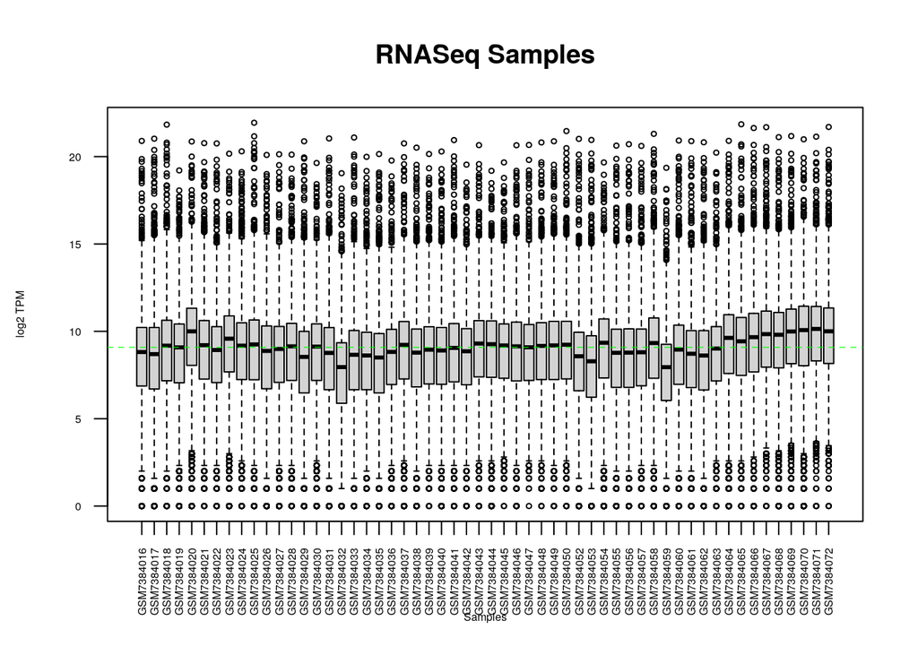

```r
plot_boxplot(filtered_raw_counts)
```

The density plots below before and after filtering shows that filtering helps to clean up a lot of the “messy” data at the lower end of the curve.

### Before filtering

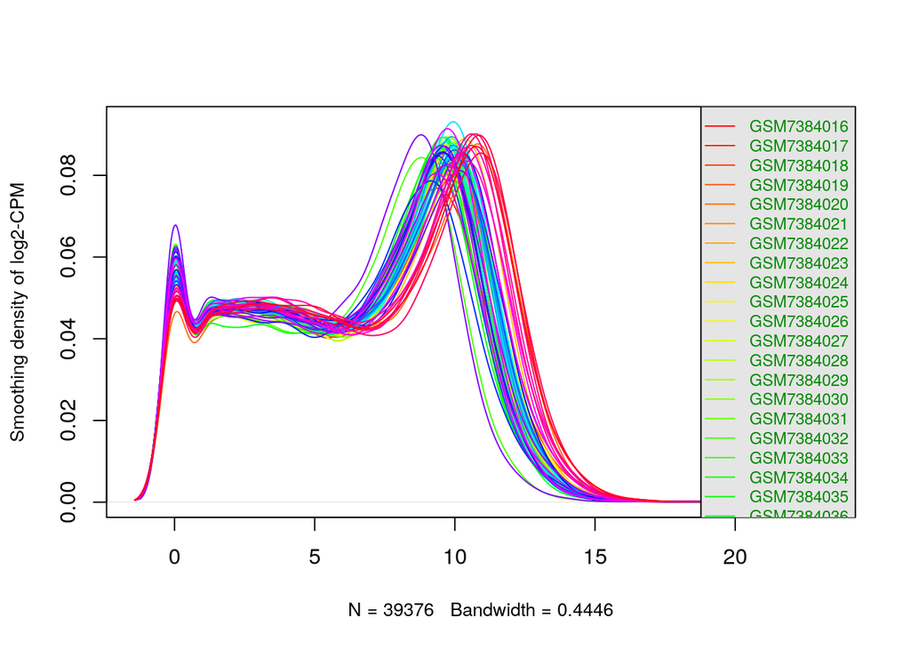

```r
density_plot(raw_counts)
```

### After filtering

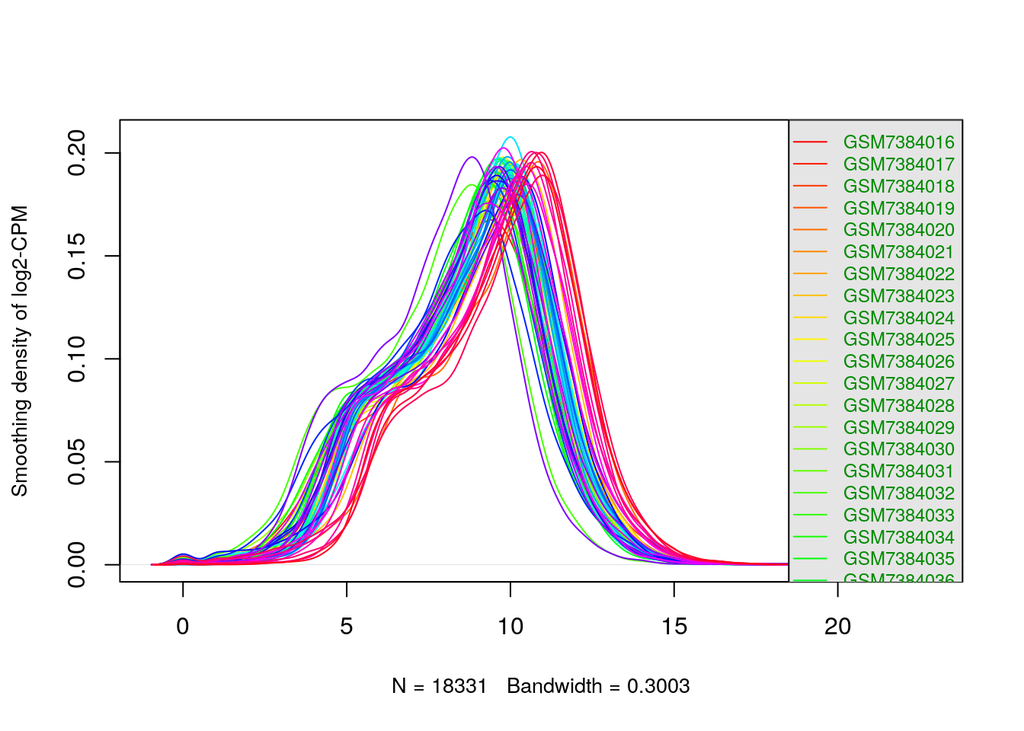

```r
density_plot(filtered_raw_counts)
```

# Normalization

To normalize, we will use the built-in counts per million (CPM) normalization in the edgeR package, which scales raw counts by the total library size to account for differences in sequencing depth. [4]

### Plots after normalization

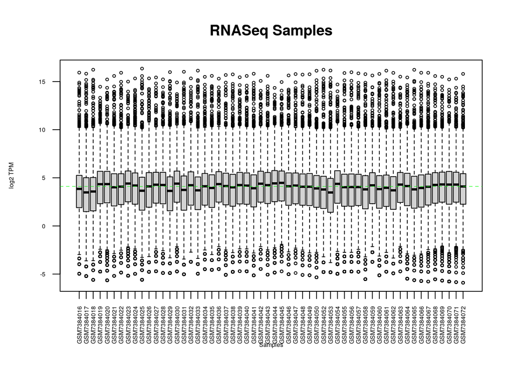

```r
plot_boxplot(normalized_counts)
```

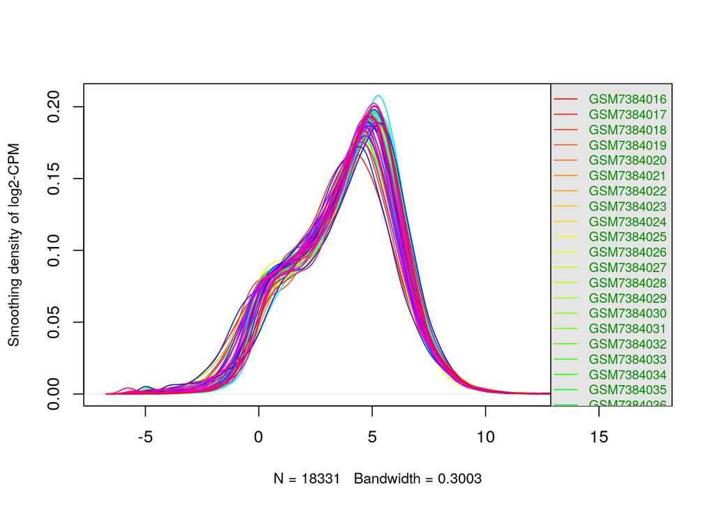

```r
density_plot(normalized_counts)
```

# MDS Plot

We use the `plotMDS()` function from the Limma package [5]:

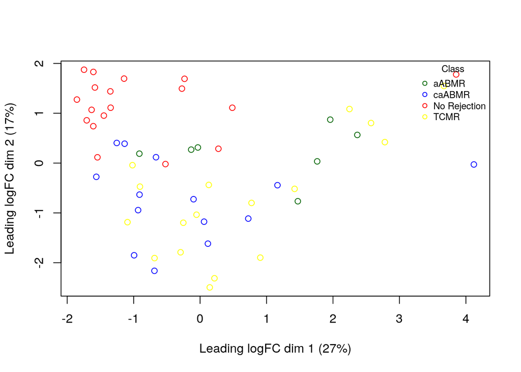

```r
limma::plotMDS(d, labels=NULL, pch = 1,
               col = c("darkgreen","blue", "red", "yellow")[factor(sample_type_dt_removed$treatment)])
legend("topright", legend=levels(factor(sample_type_dt_removed$treatment)), pch=c(1), col=c("darkgreen","blue", "red", "yellow"),title="Class", bty = 'n', cex = 0.75)
```

# Mapping to HUGO symbols

To annotate our counts matrix with HUGO gene symbols, we will be using the Human gene annotation table that is provided with all NCBI-generated RNA-seq counts matrices.

## Downloading the annotation table

```r
# Define file URL and local file path
filename <- "Human.GRCh38.p13.annot.tsv.gz"  # Local file name
path <- "https://www.ncbi.nlm.nih.gov/geo/download/?format=file&type=rnaseq_counts&file=Human.GRCh38.p13.annot.tsv.gz"

# Check if file exists locally; download only if needed
if (!file.exists(filename)) {
  message("File not found locally. Downloading...")
  download.file(path, destfile = filename, mode = "wb")
} else {
  message("File already exists locally. Skipping download.")
}
```

```
## File already exists locally. Skipping download.
```

```r
# Read the file and convert to matrix
annotation_table <- as.matrix(data.table::fread(filename, header = TRUE, colClasses = "character"), rownames = 1)
dim(annotation_table)
```

```
## [1] 39376    17
```

# Combining counts matrix with annotation table

```r
# Merge counts table with annotation by Gene ID
annotation_table_df <- as.data.frame(annotation_table)
mapping_to_hugo <- annotation_table[, "Symbol"]
merged_counts <- merge(normalized_counts, mapping_to_hugo,
                        by.x = "row.names", by.y = "row.names", all.x = TRUE)
head(merged_counts)
```

```
##   Row.names GSM7384016 GSM7384017 GSM7384018  GSM7384019 GSM7384020 GSM7384021
## 1         1  0.9579749  1.2426915  0.8229965  4.88716050  3.1446269  1.2861774
## 2        10  0.5747849  0.2161203  1.5842682  0.03730657  0.6965946  0.7115024
## 3       100  3.0335871  2.4043379  2.0986410 24.69694848  2.8261836  4.0500904
## 4      1000 46.9407695 31.7426639 44.8121574 54.95257570 26.9283553 58.3431945
## 5     10000 17.7864004  9.8604871 12.1803477 26.67419662 45.7165057 21.5366295
## 6 100008588 30.7509939 46.7360072 11.0898773 95.95249471 16.6386586 17.5960010
##   GSM7384022 GSM7384023 GSM7384024 GSM7384025 GSM7384026 GSM7384027 GSM7384028
## 1   4.040049   3.519214   3.802637  0.7045584  1.3560466  1.8758673   2.329465
## 2   1.010012   1.025283   1.235857  0.7045584  0.2931993  0.9953581   1.417935
## 3   3.378317   5.652911  18.062528  1.4091167  5.3875365  3.1392065  11.174680
## 4  41.236359  23.498377  37.931308 27.7471663 73.2631664 29.4396314  25.083949
## 5  23.369592  48.714795  18.918121 17.1373462 32.6184182 44.5231356  33.152676
## 6  15.672603  35.413827  80.806045 11.5837685 20.8171478 16.0405794  35.684703
##   GSM7384029 GSM7384030 GSM7384031  GSM7384032 GSM7384033 GSM7384034 GSM7384035
```

[output cut: 48 more lines]

# Checking the mappings

```r
mapping_to_hugo_unique <- stack(mapping_to_hugo)
mapping_to_hugo_unique <- unique(mapping_to_hugo_unique)
colnames(mapping_to_hugo_unique) <- c("Symbol", "GeneID")

duplicate_gene_mappings <- mapping_to_hugo_unique[duplicated(mapping_to_hugo_unique$GeneID) | duplicated(mapping_to_hugo_unique$GeneID, fromLast = TRUE), ]
duplicate_gene_mappings
```

```
## [1] Symbol GeneID
## <0 rows> (or 0-length row.names)
```

```r
gene_ids <- rownames(normalized_counts)
length(unique(gene_ids))
```

```
## [1] 18331
```

```r
length(gene_ids)
```

```
## [1] 18331
```

```r
any(is.na(merged_counts$y))
```

```
## [1] FALSE
```

```r
any(merged_counts$y == "")
```

```
## [1] FALSE
```

```r
symbols <- merged_counts$y
length(unique(symbols))
```

```
## [1] 18331
```

```r
length(symbols)
```

```
## [1] 18331
```

We have checked that none of the genes map to more than one HUGO symbol, that all the genes have a corresponding HUGO symbol, and there are no symbols that map to more than one gene identifier in our dataset.

1. Shah Y, Yang H, Mueller FB, Li C, Rahim SEG, Varma E, et al. Transcriptomic signatures of chronic active antibody-mediated rejection deciphered by RNA sequencing of human kidney allografts. Kidney International. 2024;105:347–63.

2. Davis S, Meltzer PS. GEOquery: A bridge between the gene expression omnibus (GEO) and BioConductor. Bioinformatics. 2007;23:1846–7.

3. Barrett T, Dowle M, Srinivasan A, Gorecki J, Chirico M, Hocking T, et al. [Data.table: Extension of ‘data.frame‘](https://r-datatable.com). 2025.

4. Chen Y, Chen L, Lun AT, Baldoni PL, Smyth GK. edgeR 4.0: Powerful differential analysis of sequencing data with expanded functionality and improved support for small counts and larger datasets. bioRxiv. 2024;2024–01.

5. Ritchie ME, Phipson B, Wu D, Hu Y, Law CW, Shi W, et al. Limma powers differential expression analyses for RNA-sequencing and microarray studies. Nucleic acids research. 2015;43:e47–7.